# Mixed Effects Models

```r
library(dplyr)
radonDataset <- read.table("srrs2.dat", header = T, sep = ",")
radonDataset <- dplyr::select(radonDataset, idnum, state, county, cntyfips, activity) %>%
                filter(state == "MN") %>%
                dplyr::select(-state) %>%
                mutate(county = trimws(county),
                       activity = log(ifelse(activity == 0, .1, activity))) %>%
                rename(logRadon = activity)
head(radonDataset, 10)
```

```
   idnum county cntyfips   logRadon
1   5081 AITKIN        1  0.7884574
2   5082 AITKIN        1  0.7884574
3   5083 AITKIN        1  1.0647107
4   5084 AITKIN        1  0.0000000
5   5085  ANOKA        3  1.1314021
6   5086  ANOKA        3  0.9162907
7   5087  ANOKA        3  0.4054651
8   5088  ANOKA        3  0.0000000
9   5089  ANOKA        3 -0.3566749
10  5090  ANOKA        3  0.1823216
```

```r
nrow(radonDataset)
```

```
[1] 919
```

```r
summarise(radonDataset, MN_counties = n_distinct(county))
```

```
  MN_counties
1          85
```

```r
tableOutput <- table(as.character(radonDataset$county))
head(tableOutput)
```

```
   AITKIN     ANOKA    BECKER  BELTRAMI    BENTON BIG STONE
        4        52         3         7         4         3
```

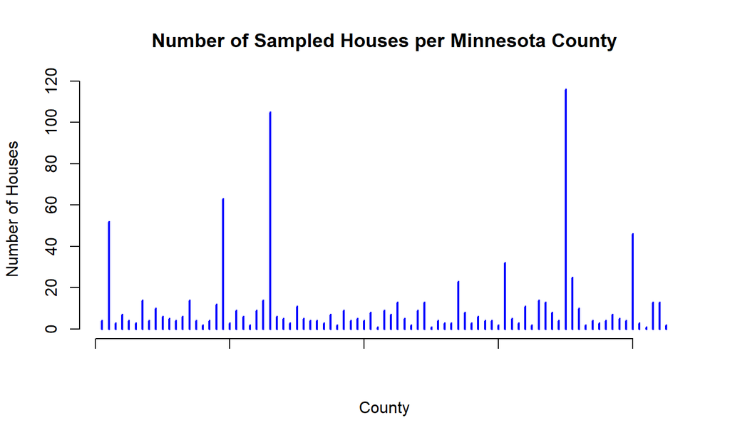

```r
plot(tableOutput, main = "Number of Sampled Houses per Minnesota County", xlab = "County",
     ylab = "Number of Houses", col = "blue", xaxt = "n")
axis(side = 1, labels = F)
```

```r
radonByCountyDataset <- radonDataset %>%
                        group_by(county) %>%
                        summarise(n = n(), averageLogRadon = round(mean(logRadon), 5)) %>%
                        as.data.frame()
head(radonByCountyDataset, 10)
```

```
       county  n averageLogRadon
1      AITKIN  4         0.66041
2       ANOKA 52         0.83325
3      BECKER  3         1.04834
4    BELTRAMI  7         1.14099
5      BENTON  4         1.25244
6   BIG STONE  3         1.51301
7  BLUE EARTH 14         1.90923
8       BROWN  4         1.62931
9     CARLTON 10         0.93098
10     CARVER  6         1.20364
```

```r
overallMean <- round(mean(radonDataset$logRadon), 5)
overallMean
```

```
[1] 1.22462
```

**Model with No Predictors**

### Complete-pooling Regression

\[y_{i} = \alpha + \epsilon_{i}\] \[\epsilon_i \sim N(0, \sigma^2)\]

- \(y_i\) is the logarithm of the radon measurement in house \(i\).
- \(\alpha\) is the mean of the logarithm of radon measurements in all houses across all counties.
- \(\sigma^2\) is the variance of the error. It measures the variability in the deviations of the radon levels in all the houses from the grand mean.

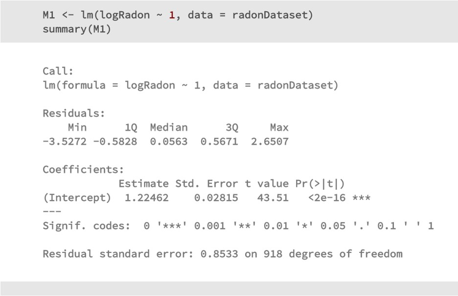

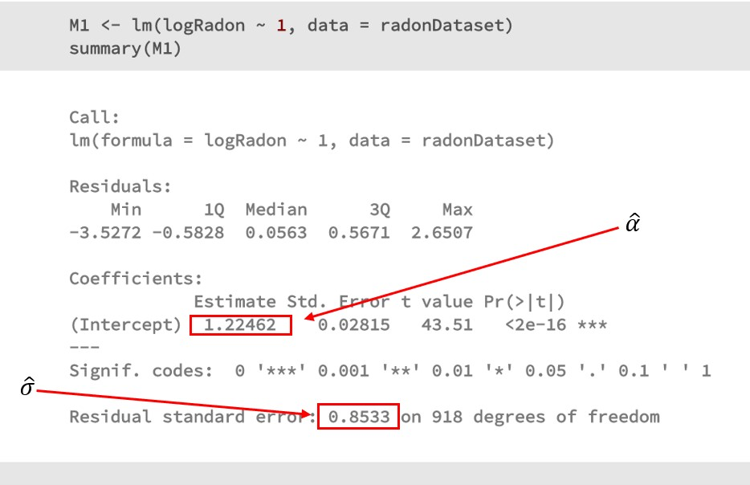

### No-pooling Regression

\[y_{i} = \sum_{k = 1}^{85} \gamma_k (county)_k + \epsilon_{i}\] \[\epsilon_i \sim N(0, \sigma^2)\]

- \(y_i\) is the logarithm of the radon measurement in house \(i\).
- \(\gamma_k\) is the mean of the logarithm of radon measurements in all houses in county \(k\).
- \(\sigma^2\) is the variance of the error. It measures the variability in the deviations of the radon levels in the houses in a county from the mean radon level of the county.

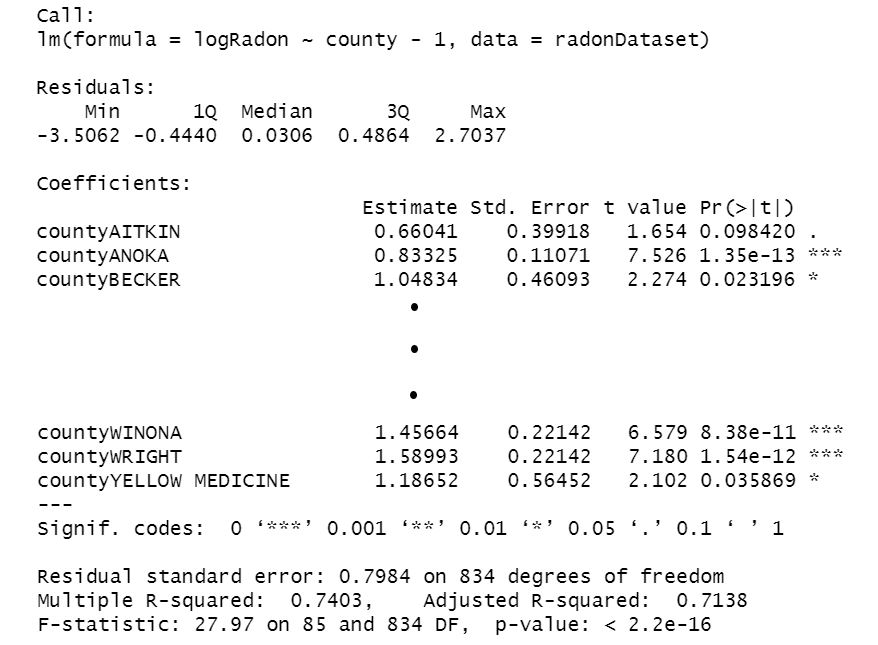

```r
M2 <- lm(logRadon ~ county - 1, data = radonDataset)
summary(M2)
```

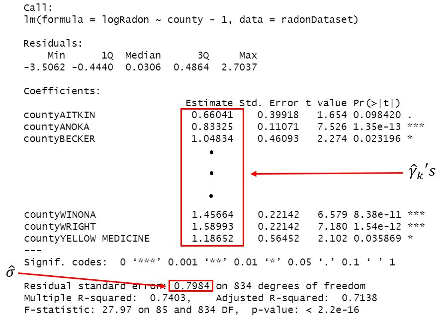

```r
M2 <- lm(logRadon ~ county - 1, data = radonDataset)
summary(M2)
```

### Multilevel Model

\[y_{i} = \alpha_{j[i]} + \epsilon_{i}\] \[\alpha_j \sim N(\mu_{\alpha}, \sigma_{\alpha}^2)\] \[\epsilon_i \sim N(0, \sigma_y^2)\]

This is a *varying-intercept model with no predictors*. It is also simply called *random intercepts model* or *unconditional means model*.

- \(y_i\) is the logarithm of the radon measurement in house \(i\).
- \(\alpha_{j[i]}\) is a random effect of county \(j\). It is the mean of the logarithm of radon measurements in all houses in county \(j\).
- \(\mu_{\alpha}\) is the mean of the logarithm of radon measurements in all houses across all counties.
- \(\sigma_{\alpha}^2\) is the variance between counties.
- \(\sigma_{y}^2\) is the variance within a county.

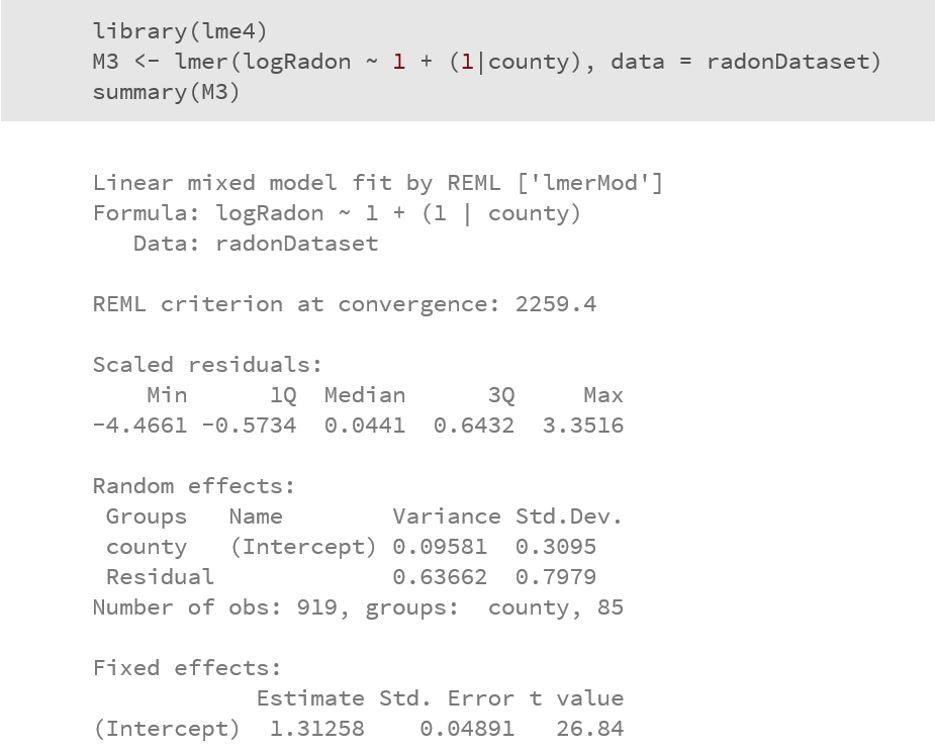

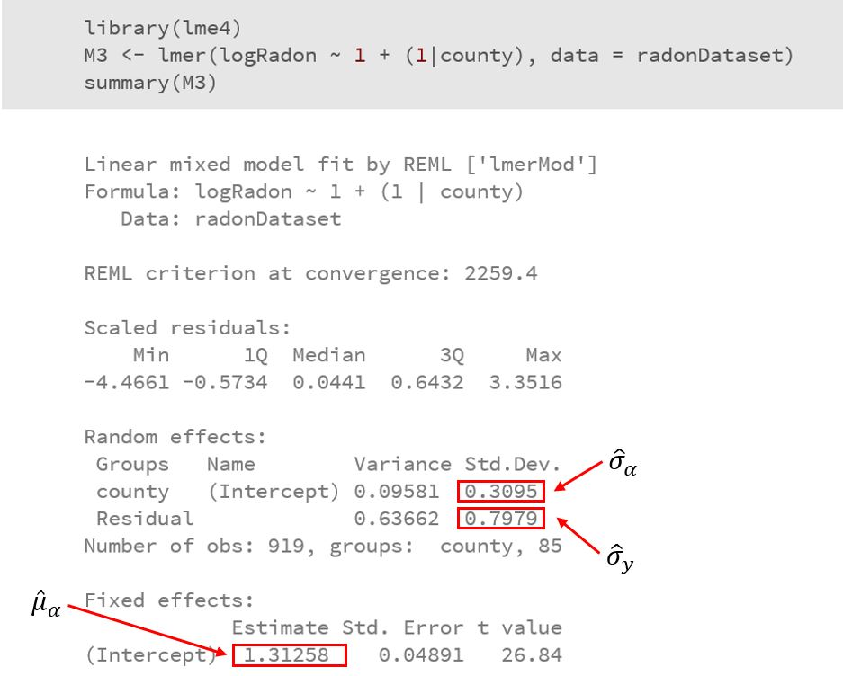

```r
head(coef(M3)$county, 5)
```

```
         (Intercept)
AITKIN     1.0674992
ANOKA      0.8875567
BECKER     1.2303811
BELTRAMI   1.2245443
BENTON     1.2899760
```

```r
fixef(M3)
```

```
(Intercept)
   1.312576
```

```r
head(ranef(M3)$county, 5)
```

```
         (Intercept)
AITKIN   -0.24507662
ANOKA    -0.42501916
BECKER   -0.08219472
BELTRAMI -0.08803149
BENTON   -0.02259986
```

```r
colnames(radonByCountyDataset)[3] <- "noPooling"
radonByCountyDataset$completePooling <- overallMean
radonByCountyDataset$multilevel <- coef(M3)$county$`(Intercept)`
head(radonByCountyDataset, 10)
```

```
       county  n noPooling completePooling multilevel
1      AITKIN  4   0.66041         1.22462  1.0674992
2       ANOKA 52   0.83325         1.22462  0.8875567
3      BECKER  3   1.04834         1.22462  1.2303811
4    BELTRAMI  7   1.14099         1.22462  1.2245443
5      BENTON  4   1.25244         1.22462  1.2899760
6   BIG STONE  3   1.51301         1.22462  1.3749236
7  BLUE EARTH 14   1.90923         1.22462  1.7171956
8       BROWN  4   1.62931         1.22462  1.4315992
9     CARLTON 10   0.93098         1.22462  1.0833130
10     CARVER  6   1.20364         1.22462  1.2608819
```

```r
sigmas <- arm::sigma.hat(M3)$sigma
sigmas
```

```
$data
[1] 0.797885

$county
(Intercept)
  0.3095384
```

```r
icc <- sigmas$county^2/(sigmas$county^2 + sigmas$data^2)
icc
```

```
(Intercept)
  0.1308158
```

**Model with a Unit-Level Predictor**

```r
floorDataset <- read.table("srrs2.dat", header = T, sep = ",")
floorDataset <- dplyr::select(floorDataset, idnum, state, floor) %>%
                filter(state == "MN") %>%
                dplyr::select(-state)
radonDataset <- merge(radonDataset, floorDataset)
head(radonDataset, 10)
```

```
   idnum county cntyfips   logRadon floor
1   5081 AITKIN        1  0.7884574     1
2   5082 AITKIN        1  0.7884574     0
3   5083 AITKIN        1  1.0647107     0
4   5084 AITKIN        1  0.0000000     0
5   5085  ANOKA        3  1.1314021     0
6   5086  ANOKA        3  0.9162907     0
7   5087  ANOKA        3  0.4054651     0
8   5088  ANOKA        3  0.0000000     0
9   5089  ANOKA        3 -0.3566749     0
10  5090  ANOKA        3  0.1823216     0
```

### Complete-pooling Regression

\[y_{i} = \alpha + \beta (floor)_i + \epsilon_{i}\] \[\epsilon_i \sim N(0, \sigma^2)\]

- \(y_i\) is the logarithm of the radon measurement in house \(i\).
- \(\alpha\) is the mean of the logarithm of radon measurements that are taken at the basement.
- \(\beta\) is the average difference between the logarithm of radon measurements taken on the first floor and the logarithm of radon measurements taken at the basement.
- \(\sigma^2\) is the variance of the error.

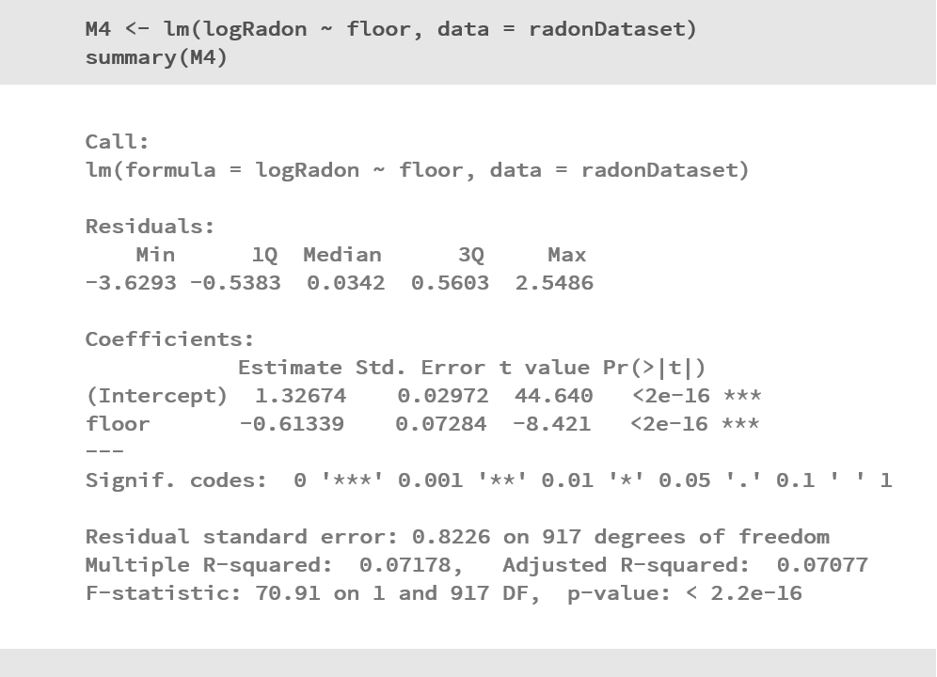

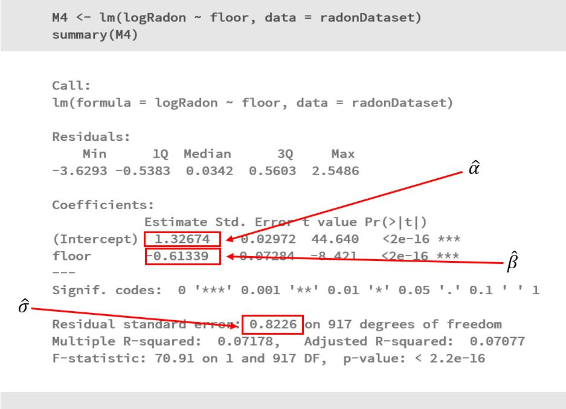